# 11.21.20_Case_Study_2

Zach Zaiken

11/21/2020

```r
knitr::opts_chunk$set(fig.path='Figs/')
```

# Introduction

The analysis and code are based off of the employee information provided by Frito/Lay. The findings from the DDS Analytics Company, were prepared and are represented by data scientist Zach Zaiken. In the Code and presentation attached , DDS Analytics will be providing data inferences and key takeaways for each of the Frito/Lay Team’s questions and inquries. The presentation is divided up into the sections below.

1. Import Data
2. Factors Of Attrition
1. JobRole
2. Monthly Income
3. Over Time
3. Attrition Classification via Naive-Bayes
4. Prediction of Attrition
5. Job Specific Trends
6. Monthly Income Regression Model
7. Monthly Income Regression Model (Cross-Validation)
8. Monthly Income Regression Model (Prediction)
9. Export of CompSet CSV files

# Import Data

The following code imports the primary employee dataset that will be used to identify attrition classification/prediction, Jobe Role specific trends and Monthly Income regression analysis. In addition the Compsets are brought in for Attrition and Salaries which we be used to test the cross validared prediction models for attrition and monthly income.

```r
library (readr)

casestudy2data_urlfile="https://raw.githubusercontent.com/zz415/SMU_DDS_6306_CaseStudy2/main/raw_data_csv/CaseStudy2-data.csv"
casestudy2CompSet_NoAtr_urlfile="https://raw.githubusercontent.com/zz415/SMU_DDS_6306_CaseStudy2/main/raw_data_csv/CaseStudy2CompSet%20No%20Attrition.csv"
casestudy2CompSet_NoSal_urlfile="https://raw.githubusercontent.com/zz415/SMU_DDS_6306_CaseStudy2/main/raw_data_csv/CaseStudy2CompSet%20No%20Salary.csv"



CaseStudy2_data <-read_csv(url(casestudy2data_urlfile))
CaseStudy2_CompSet_NoAtr <-read_csv(url(casestudy2CompSet_NoAtr_urlfile))
CaseStudy2_CompSet_NoSal <-read_csv(url(casestudy2CompSet_NoSal_urlfile))
```

# Factors Of Attrition

The overall employee attrition of the data set is 16%. The following sections and code will review the 3 primary factors driving attrition. The code below summarizes Total attrition of the sample set.

```r
library(kableExtra)
library(knitr)
library(tidyverse)

data.frame(
 Total_Employee_Count = nrow(CaseStudy2_data),
 Attrition_Count = nrow(CaseStudy2_data%>%filter(Attrition=="Yes")),
 Attrition_Percent = nrow(CaseStudy2_data%>%filter(Attrition=="Yes"))/nrow(CaseStudy2_data)) %>%
  kbl() %>%
  kable_classic_2(full_width = F)%>%
  add_header_above(c("Overall Employee Attrition" = 3))
```

| Overall Employee Attrition Total_Employee_Count | Overall Employee Attrition Attrition_Count | Overall Employee Attrition Attrition_Percent |
| --- | --- | --- |
| 870 | 140 | 0.1609195 |

### JobRole

The code below summarizes attrition related statistics by JobRole from the sample set The code creates dataframes that show the attrition percentage, and cumulative attrition percentage for each JobRole. In addition visualizations are created reflecting the results in the table below

1. Attrition seems to be heavily tied to 4 JobRoles within the company:
   1. Sales Executive
   2. Research Scientist
   3. Laboratory Technician
   4. Sales Representative
2. These 4 roles account for 85% of the total attrition among employees
3. Furthermore, these 4 roles have the highest Job specific Attrition rates out of all listed Jobroles (The one exception being human resources, which could be due to its small sample size)
4. Based on the average job level there is correlation these are also lower position or entry level jobs, which may also tie into attrition motivations

```r
library(tidyverse)
library(knitr)
#install.packages("kableExtra")
library(kableExtra)

ATR_comp <- left_join(

CaseStudy2_data%>%group_by(JobRole)%>%summarize(count=n(),Avg_Job_Level=mean(JobLevel)),

CaseStudy2_data%>%filter(Attrition=="Yes")%>%group_by(JobRole)%>%summarize(ATR_count=n()),
by=c("JobRole"="JobRole"))%>%mutate('JobRole_ATR_%' = ATR_count/count)%>%arrange(desc(ATR_count))

ATR_comp$'%_Of_Total_ATR' = ATR_comp$ATR_count/nrow(CaseStudy2_data%>%filter(Attrition=="Yes"))
ATR_comp$Cumulative_ATR_count = cumsum(ATR_comp$ATR_count)
ATR_comp$'Cumulative_ATR_%' = ATR_comp$Cumulative_ATR_count/nrow(CaseStudy2_data%>%filter(Attrition=="Yes"))

as.data.frame(ATR_comp) %>%
  kbl() %>%
  kable_classic_2(full_width = F)%>%
  add_header_above(c(" ", "JobRole Attrition Statistics" = 7))
```

| JobRole | JobRole Attrition Statistics count | JobRole Attrition Statistics Avg_Job_Level | JobRole Attrition Statistics ATR_count | JobRole Attrition Statistics JobRole_ATR_% | JobRole Attrition Statistics %_Of_Total_ATR | JobRole Attrition Statistics Cumulative_ATR_count | JobRole Attrition Statistics Cumulative_ATR_% |
| --- | --- | --- | --- | --- | --- | --- | --- |
| Sales Executive | 200 | 2.335000 | 33 | 0.1650000 | 0.2357143 | 33 | 0.2357143 |
| Research Scientist | 172 | 1.186047 | 32 | 0.1860465 | 0.2285714 | 65 | 0.4642857 |
| Laboratory Technician | 153 | 1.267974 | 30 | 0.1960784 | 0.2142857 | 95 | 0.6785714 |
| Sales Representative | 53 | 1.056604 | 24 | 0.4528302 | 0.1714286 | 119 | 0.8500000 |
| Healthcare Representative | 76 | 2.460526 | 8 | 0.1052632 | 0.0571429 | 127 | 0.9071429 |
| Human Resources | 27 | 1.222222 | 6 | 0.2222222 | 0.0428571 | 133 | 0.9500000 |
| Manager | 51 | 4.333333 | 4 | 0.0784314 | 0.0285714 | 137 | 0.9785714 |
| Manufacturing Director | 87 | 2.459770 | 2 | 0.0229885 | 0.0142857 | 139 | 0.9928571 |
| Research Director | 51 | 3.882353 | 1 | 0.0196078 | 0.0071429 | 140 | 1.0000000 |

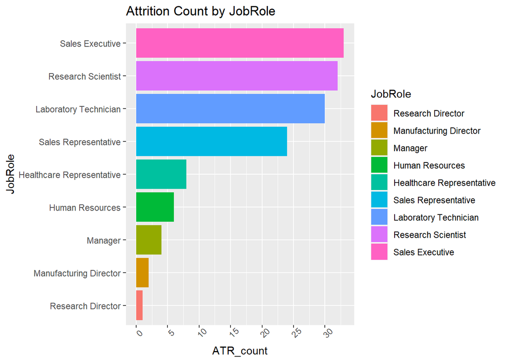

```r
ATR_comp$JobRole = factor(ATR_comp$JobRole,level = ATR_comp$JobRole[order((ATR_comp$ATR_count))])


ATR_comp%>%ggplot(aes(x=JobRole,y=ATR_count,fill=JobRole))+
  geom_col()+
  theme(axis.text.x = element_text(angle = 45))+
 scale_y_continuous(breaks = scales::pretty_breaks(n = 10))+ coord_flip()+ggtitle("Attrition Count by JobRole")
```

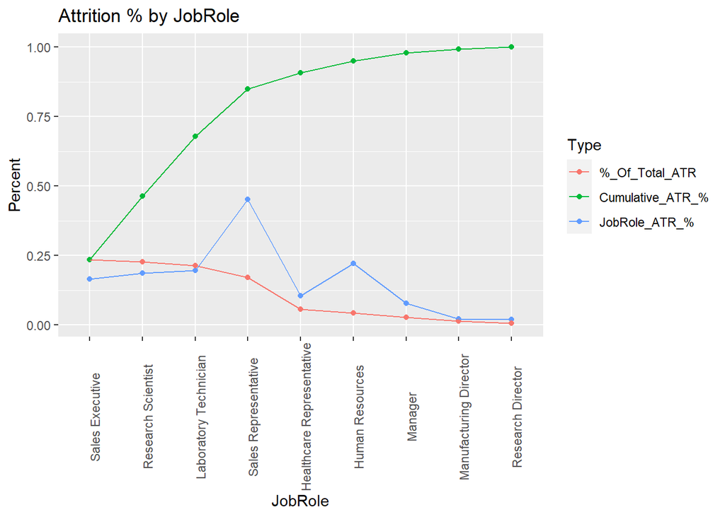

```r
ATR_comp$JobRole = factor(ATR_comp$JobRole,level = ATR_comp$JobRole[order((ATR_comp$ATR_count),decreasing = TRUE)])

rbind(
ATR_comp%>%mutate(Type='JobRole_ATR_%')%>%select(JobRole,Percent='JobRole_ATR_%',Type),
ATR_comp%>%mutate(Type='%_Of_Total_ATR')%>%select(JobRole,Percent='%_Of_Total_ATR',Type),
ATR_comp%>%mutate(Type='Cumulative_ATR_%')%>%select(JobRole,Percent='Cumulative_ATR_%',Type))%>%
  ggplot(aes(x = JobRole,y=Percent,group=Type,color=Type)) +

  geom_point()+geom_line()+
  theme(axis.text.x = element_text(angle = 90))+ggtitle("Attrition % by JobRole")
```

### Monthly Income

The following code examines the relationship between Attrition and Monthly Income. To better standardize the data for a histogram and the Naive-Bayes classification model in the section to come, Income is rounded to the nearest $1000 value.

1. Attrition is greatly skewed to employees with lower Monthly Income
2. Incomes <= $5000 account for 73% of the total attrition among employees despite only being 58% of the total employee count
3. Very high attrition level in Incomes rounded to 1K, 2K & 3K (54%,32%,20%) vs the attrition rate of employees making over 5K (10%)

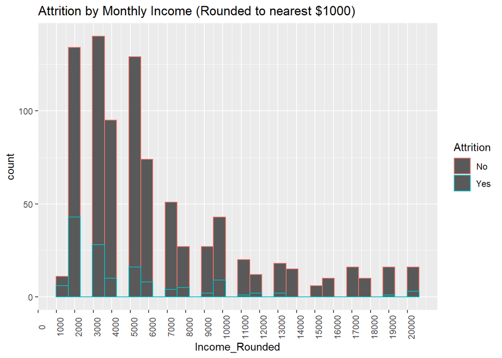

```r
library(plyr)
CaseStudy2_data$Income_Rounded = round_any(CaseStudy2_data$MonthlyIncome, 1000)
CaseStudy2_data%>%
  ggplot(aes(x=Income_Rounded,color=Attrition))+geom_histogram()+
  scale_x_continuous(breaks = round(seq(0,20000, by = 1000),2000))+
  theme(axis.text.x = element_text(angle = 90))+ggtitle("Attrition by Monthly Income (Rounded to nearest $1000)")
```

```r
detach("package:plyr", unload=TRUE)
library(tidyverse)
ATR_income_comp <- left_join(

CaseStudy2_data%>%group_by(Income_Rounded)%>%summarize(count=n()),

CaseStudy2_data%>%filter(Attrition=="Yes")%>%group_by(Income_Rounded)%>%summarize(ATR_count=n()),
by=c("Income_Rounded"="Income_Rounded"))%>%mutate('Income_ATR_%' = ATR_count/count)%>%arrange((Income_Rounded))

ATR_income_comp$'%_Of_Total_ATR' = ATR_income_comp$ATR_count/nrow(CaseStudy2_data%>%filter(Attrition=="Yes"))
ATR_income_comp$Cumulative_ATR_count = cumsum(ATR_income_comp$ATR_count)
ATR_income_comp$'Cumulative_ATR_%' = ATR_income_comp$Cumulative_ATR_count/nrow(CaseStudy2_data%>%filter(Attrition=="Yes"))
ATR_income_comp$'Cumulative_Employee_%' = cumsum(ATR_income_comp$count)/nrow(CaseStudy2_data)







head_df <- ATR_income_comp%>%head(5)


tail_df <- tail(ATR_income_comp,-5)
tail_df[is.na(tail_df)] = 0

tail_df2<- data.frame(
Income_Rounded = c("Over 5000"),
c(tail_df%>%summarize(count=sum(count))),
c(tail_df%>%summarize(ATR_count = sum(ATR_count))),
 c(tail_df%>%summarize( 'Income_ATR_%'= sum(ATR_count))/tail_df%>%summarize(count=sum(count))),
tail_df%>%summarize('%_Of_Total_ATR' = sum(ATR_count))/nrow(CaseStudy2_data%>%filter(Attrition=="Yes")),
Cumulative_ATR_count = nrow(CaseStudy2_data%>%filter(Attrition=="Yes")),
'Cumulative_ATR_%' = 1,
'Cumulative_Employee_%' = 1



)%>%
  rename(
    'Income_ATR_%' = Income_ATR_.,
   '%_Of_Total_ATR' = X._Of_Total_ATR,
   'Cumulative_ATR_%'= Cumulative_ATR_.,
   'Cumulative_Employee_%' =Cumulative_Employee_.
    )

head_df$Income_Rounded = as.character(head_df$Income_Rounded)
union_all(head_df,tail_df2)%>%
  kbl() %>%
  kable_classic_2(full_width = F)%>%
  add_header_above(c("Monthly Income Attrition Statistics" = 8))
```

| Monthly Income Attrition Statistics Income_Rounded | Monthly Income Attrition Statistics count | Monthly Income Attrition Statistics ATR_count | Monthly Income Attrition Statistics Income_ATR_% | Monthly Income Attrition Statistics %_Of_Total_ATR | Monthly Income Attrition Statistics Cumulative_ATR_count | Monthly Income Attrition Statistics Cumulative_ATR_% | Monthly Income Attrition Statistics Cumulative_Employee_% |
| --- | --- | --- | --- | --- | --- | --- | --- |
| 1000 | 11 | 6 | 0.5454545 | 0.0428571 | 6 | 0.0428571 | 0.0126437 |
| 2000 | 134 | 43 | 0.3208955 | 0.3071429 | 49 | 0.3500000 | 0.1666667 |
| 3000 | 140 | 28 | 0.2000000 | 0.2000000 | 77 | 0.5500000 | 0.3275862 |
| 4000 | 95 | 10 | 0.1052632 | 0.0714286 | 87 | 0.6214286 | 0.4367816 |
| 5000 | 129 | 16 | 0.1240310 | 0.1142857 | 103 | 0.7357143 | 0.5850575 |
| Over 5000 | 361 | 37 | 0.1024931 | 0.2642857 | 140 | 1.0000000 | 1.0000000 |

### OverTime

The following code provides Analysis showing the large difference in attrition percentages between overtime and non-overtime employees. In addition code is written to calculate the 2 sample test for equality of proportions to highlight the statistical significance of this gap.

1. Attrition for Overtime workers is 3-fold that of Non-Overtime employees (31% vs 9%)
2. Overtime workers account for 57% of all employee attrition but account for only 28% of the employee count
3. 2 Sample test for equality of proportions confirms with statistical significance (p-value < .0001) that the attrition % of Overtime vs Non- Overtime employees are not equal (95% confidence interval [15.5% - 28.5%])

```r
library(tidyverse)
library(knitr)
#install.packages("kableExtra")
library(kableExtra)

ATR_comp_OT <- left_join(

CaseStudy2_data%>%group_by(OverTime)%>%summarize(count=n()),

CaseStudy2_data%>%filter(Attrition=="Yes")%>%group_by(OverTime)%>%summarize(ATR_count=n()),
by=c("OverTime"="OverTime"))%>%mutate('OverTime_ATR_%' = ATR_count/count)%>%arrange(desc(ATR_count))

ATR_comp_OT$'%_Of_Total_ATR' = ATR_comp_OT$ATR_count/nrow(CaseStudy2_data%>%filter(Attrition=="Yes"))
ATR_comp_OT$Cumulative_ATR_count = cumsum(ATR_comp_OT$ATR_count)
ATR_comp_OT$'Cumulative_ATR_%' = ATR_comp_OT$Cumulative_ATR_count/nrow(CaseStudy2_data%>%filter(Attrition=="Yes"))


as.data.frame(ATR_comp_OT) %>%
  kbl() %>%
  kable_classic_2(full_width = F)%>%
  add_header_above(c( "OverTime Attrition Statistics" = 7))
```

| OverTime Attrition Statistics OverTime | OverTime Attrition Statistics count | OverTime Attrition Statistics ATR_count | OverTime Attrition Statistics OverTime_ATR_% | OverTime Attrition Statistics %_Of_Total_ATR | OverTime Attrition Statistics Cumulative_ATR_count | OverTime Attrition Statistics Cumulative_ATR_% |
| --- | --- | --- | --- | --- | --- | --- |
| Yes | 252 | 80 | 0.3174603 | 0.5714286 | 80 | 0.5714286 |
| No | 618 | 60 | 0.0970874 | 0.4285714 | 140 | 1.0000000 |

```r
library(MASS)
OT_data <- CaseStudy2_data%>%mutate(Overtime_CAT = ifelse(OverTime == "Yes","Overtime","Non-Overtime"), Attrition_CAT = ifelse(Attrition == "Yes","Attrition","Non-Attrition"))


table(OT_data$Overtime_CAT, OT_data$Attrition_CAT)%>%
  kbl()%>%
  kable_classic_2(full_width = F)%>%
  add_header_above(c( "Inputs for Two-Proportions Z-Test " = 3))
```

| Inputs for Two-Proportions Z-Test | Inputs for Two-Proportions Z-Test Attrition | Inputs for Two-Proportions Z-Test Non-Attrition |
| --- | --- | --- |
| Non-Overtime | 60 | 558 |
| Overtime | 80 | 172 |

```r
prop.test(x = c(80, 60), n = c(252, 618))
```

```
##
##  2-sample test for equality of proportions with continuity correction
##
## data:  c(80, 60) out of c(252, 618)
## X-squared = 62.762, df = 1, p-value = 2.333e-15
## alternative hypothesis: two.sided
## 95 percent confidence interval:
##  0.1555480 0.2851978
## sample estimates:
##     prop 1     prop 2
## 0.31746032 0.09708738
```

```r
detach("package:MASS", unload=TRUE)
```

# Attrition Classification via Naive-Bayes

While there are some variables that show strong correlation to Attrition, the true correlation and assigning an attrition prediction to workers will involve many more variables and considerations. The data provided by the employer is a mix of both continuous and categorical variables. As such using KNN and measuring euclidean distances will not be appropriate.

The following code will run a Naive-Bayes Model (abbreviated as NB) to test the statistical evidence of correlation between variables. The concept of NB is any employee will be categorized as either Attrition or Non-Attrition depending based on conditional probabilities of the included variables. It works on Bayes theorem of probability to predict the class of data sets.

The variables tested with the Naive-Bayes Model include: 1) JobRole 2) JobLevel 3) JobSatisfaction  
4) JobInvolvement 5) YearsAtCompany 6) OverTime 7) StockOptionLevel 8) TotalWorkingYears 9) BusinessTravel 10) Age 11) MaritalStatus 12) EnvironmentSatisfaction 13) NumCompaniesWorked 14) Income_Rounded 15) DistanceFromHome 16) WorkLifeBalance 17) YearsWithCurrManager 18) YearsInCurrentRole

The NB will return 3 primary statistics:

1. Accuracy: the number of all correct predictions divided by the total number of the dataset
2. Sensitivity: the number of correct positive predictions divided by the total number of positives
3. Specificity: the number of correct negative predictions divided by the total number of negatives

```r
library(e1071)
library(class)
library(caret)
library(knitr)
#install.packages("kableExtra")
library(kableExtra)
library(tidyverse)

iterations_nb = 500
masterAcc_nb = matrix(nrow = iterations_nb)
masterSens_nb = matrix(nrow = iterations_nb)
masterSpef_nb = matrix(nrow = iterations_nb)
splitPerc = .7 #Training / Test split Percentage
for(j in 1:iterations_nb)
{

  trainIndices_nb = sample(1:dim(CaseStudy2_data)[1],round(splitPerc * dim(CaseStudy2_data)[1]))
  train_nb = CaseStudy2_data[trainIndices_nb,]
  test_nb = CaseStudy2_data[-trainIndices_nb,]

  model_nb = naiveBayes(train_nb%>%dplyr::select(JobRole,
    JobLevel,
    JobSatisfaction,
    JobInvolvement,
    YearsAtCompany,
    OverTime,
    StockOptionLevel,
    TotalWorkingYears,
    BusinessTravel,
    Age,
    MaritalStatus,
    EnvironmentSatisfaction,
    NumCompaniesWorked,
    Income_Rounded,
    DistanceFromHome,
    WorkLifeBalance,
    YearsWithCurrManager,
    YearsInCurrentRole

 ),as.factor(train_nb$Attrition),laplace = 1)
  table(predict(model_nb,test_nb%>%
  dplyr::select(
    JobRole,
    JobLevel,
    JobSatisfaction,
    JobInvolvement,
    YearsAtCompany,
    OverTime,
    StockOptionLevel,
    TotalWorkingYears,
    BusinessTravel,
    Age,
    MaritalStatus,
    EnvironmentSatisfaction,
    NumCompaniesWorked,
    Income_Rounded,
    DistanceFromHome,
    WorkLifeBalance,
    YearsWithCurrManager,
    YearsInCurrentRole

)),as.factor(test_nb$Attrition
))
  CM_nb = confusionMatrix(table(predict(model_nb,test_nb%>%
dplyr::select(

    JobRole,
    JobLevel,
    JobSatisfaction,
    JobInvolvement,
    YearsAtCompany,
    OverTime,
    StockOptionLevel,
    TotalWorkingYears,
    BusinessTravel,
    Age,
    MaritalStatus,
    EnvironmentSatisfaction,
    NumCompaniesWorked,
    Income_Rounded,
    DistanceFromHome,
    WorkLifeBalance,
    YearsWithCurrManager,
    YearsInCurrentRole

       )),as.factor(test_nb$Attrition)))
  masterAcc_nb[j] = CM_nb$overall[1]
  masterSens_nb[j] = CM_nb$byClass[1]
  masterSpef_nb[j] = CM_nb$byClass[2]
}
MeanAcc_nb = colMeans(masterAcc_nb)
MeanSens_nb = colMeans(masterSens_nb)
MeanSpef_nb = colMeans(masterSpef_nb)

nb_results <- data.frame(
                          accuracy_avg = MeanAcc_nb,
                          Sensitivity_avg = MeanSens_nb,
                          Specificity_avg = MeanSpef_nb)#%>%gt()%>%tab_header(title = "Naive-Bayes (500 iterations)")







data.frame( Attrition_Factors_Considered = names(train_nb%>%select(
    JobRole,
    JobLevel,
    JobSatisfaction,
    JobInvolvement,
    YearsAtCompany,
    OverTime,
    StockOptionLevel,
    TotalWorkingYears,
    BusinessTravel,
    Age,
    MaritalStatus,
    EnvironmentSatisfaction,
    NumCompaniesWorked,
    Income_Rounded,
    DistanceFromHome,
    WorkLifeBalance,
    YearsWithCurrManager,
    YearsInCurrentRole

 )

 ))%>%
  kbl() %>%
  kable_classic_2(full_width = F)%>%
  add_header_above(c( "Inputs for Naive-Bayes Classification Model" = 1))
```

| Inputs for Naive-Bayes Classification Model Attrition_Factors_Considered |
| --- |
| JobRole |
| JobLevel |
| JobSatisfaction |
| JobInvolvement |
| YearsAtCompany |
| OverTime |
| StockOptionLevel |
| TotalWorkingYears |
| BusinessTravel |
| Age |
| MaritalStatus |
| EnvironmentSatisfaction |
| NumCompaniesWorked |
| Income_Rounded |
| DistanceFromHome |
| WorkLifeBalance |
| YearsWithCurrManager |
| YearsInCurrentRole |

```r
nb_results %>%
  kbl() %>%
  kable_classic_2(full_width = F)%>%
  add_header_above(c( "Naive-Bayes Cross-Validation (500 iterations of 70/30 Test&Train Sets)" = 3))
```

| Naive-Bayes Cross-Validation (500 iterations of 70/30 Test&Train Sets) accuracy_avg | Naive-Bayes Cross-Validation (500 iterations of 70/30 Test&Train Sets) Sensitivity_avg | Naive-Bayes Cross-Validation (500 iterations of 70/30 Test&Train Sets) Specificity_avg |
| --- | --- | --- |
| 0.8009042 | 0.8351482 | 0.6266871 |

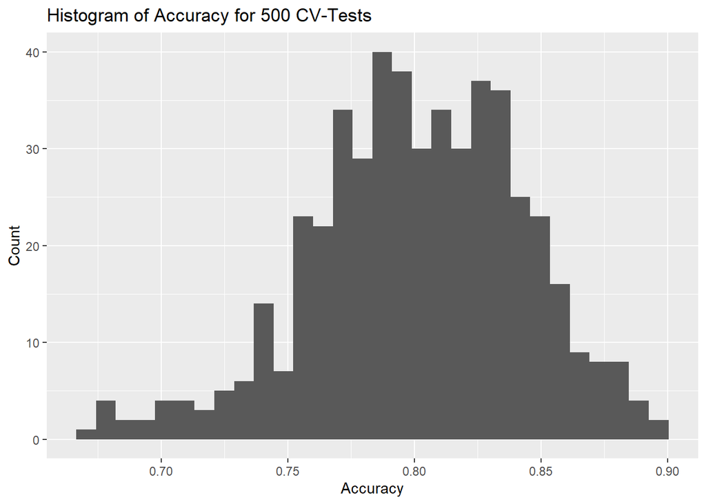

```r
as.data.frame(masterAcc_nb)%>%ggplot(aes(x=V1))+geom_histogram()+xlab("Accuracy")+ylab("Count")+ggtitle("Histogram of Accuracy for 500 CV-Tests")
```

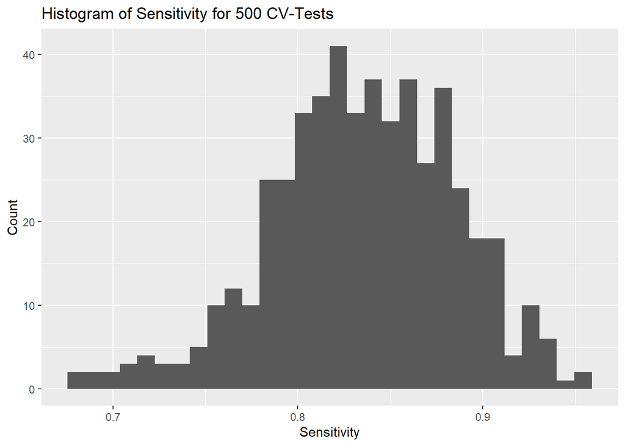

```r
as.data.frame(masterSens_nb)%>%ggplot(aes(x=V1))+geom_histogram()+xlab("Sensitivity")+ylab("Count")+ggtitle("Histogram of Sensitivity for 500 CV-Tests")
```

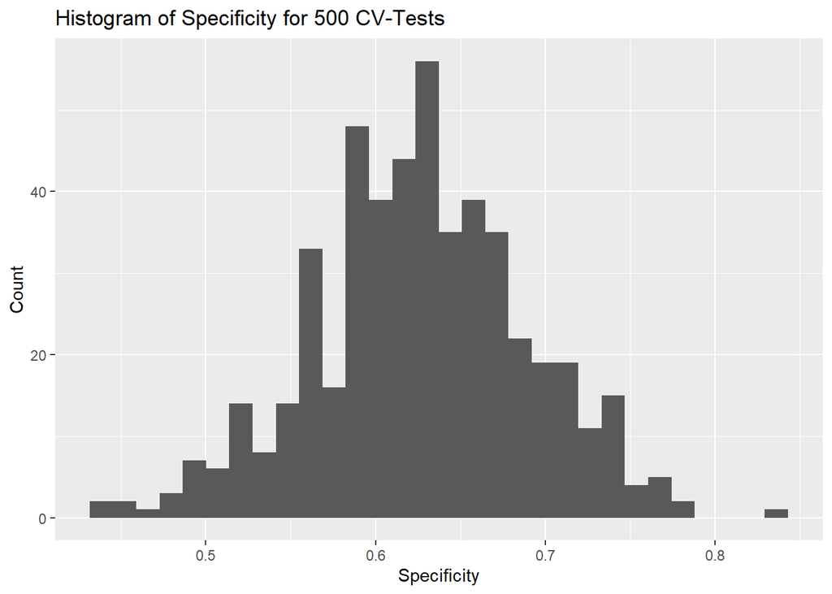

```r
as.data.frame(masterSpef_nb)%>%ggplot(aes(x=V1))+geom_histogram()+xlab("Specificity")+ylab("Count")+ggtitle("Histogram of Specificity for 500 CV-Tests")
```

### Prediction of Attrition

The following code uses the previously built and cross-validated Naive-Bayes classification model to make an Attrition prediction on the additional CompSet of 300 employees. In addition the code provides summaries as to the results of the 3 previously identified primary factors of attrition.

```r
library(e1071)
library(class)
library(caret)
library(knitr)
#install.packages("kableExtra")
library(kableExtra)

library(plyr)

CaseStudy2_CompSet_NoAtr$Income_Rounded = round_any(CaseStudy2_CompSet_NoAtr$MonthlyIncome, 1000)

 detach("package:plyr", unload=TRUE)
library(tidyverse)
model_nb_predict = naiveBayes(CaseStudy2_data%>%select(
    JobRole,
    JobLevel,
    JobSatisfaction,
    JobInvolvement,
    YearsAtCompany,
    OverTime,
    StockOptionLevel,
    TotalWorkingYears,
    BusinessTravel,
    Age,
    MaritalStatus,
    EnvironmentSatisfaction,
    NumCompaniesWorked,
    Income_Rounded,
    DistanceFromHome,
    WorkLifeBalance,
    YearsWithCurrManager,
    YearsInCurrentRole

 ),as.factor(CaseStudy2_data$Attrition),laplace = 1)


 CompSet_ATR_Pred<- predict(model_nb,CaseStudy2_CompSet_NoAtr%>%
  select(
    JobRole,
    JobLevel,
    JobSatisfaction,
    JobInvolvement,
    YearsAtCompany,
    OverTime,
    StockOptionLevel,
    TotalWorkingYears,
    BusinessTravel,
    Age,
    MaritalStatus,
    EnvironmentSatisfaction,
    NumCompaniesWorked,
    Income_Rounded,
    DistanceFromHome,
    WorkLifeBalance,
    YearsWithCurrManager,
    YearsInCurrentRole

))


CaseStudy2_CompSet_NoAtr$ATR_Prediction = as.character(CompSet_ATR_Pred)





Case2PredictionsZaiken <- CaseStudy2_CompSet_NoAtr%>%mutate(Attrition = ATR_Prediction)%>%select(ID,Attrition)




data.frame(
 Total_Employee_Count = nrow(CaseStudy2_CompSet_NoAtr),
 Attrition_Count = nrow(CaseStudy2_CompSet_NoAtr%>%filter(ATR_Prediction=="Yes")),
 Attrition_Percent = nrow(CaseStudy2_CompSet_NoAtr%>%filter(ATR_Prediction=="Yes"))/nrow(CaseStudy2_CompSet_NoAtr)) %>%
  kbl() %>%
  kable_classic_2(full_width = F)%>%
  add_header_above(c("Predicted Employee Attrition on CompSet" = 3))
```

| Predicted Employee Attrition on CompSet Total_Employee_Count | Predicted Employee Attrition on CompSet Attrition_Count | Predicted Employee Attrition on CompSet Attrition_Percent |
| --- | --- | --- |
| 300 | 72 | 0.24 |

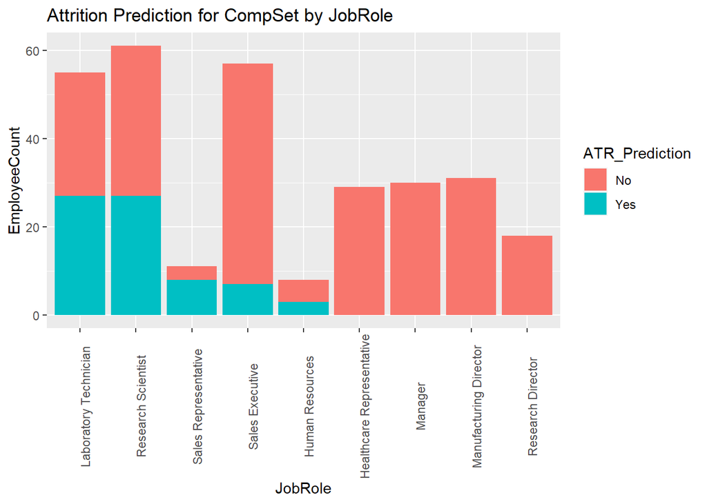

```r
CaseStudy2_CompSet_NoAtr_Jrole <- left_join(
CaseStudy2_CompSet_NoAtr%>%group_by(JobRole)%>%summarize(count=n()),
CaseStudy2_CompSet_NoAtr%>%filter(ATR_Prediction=="Yes")%>%group_by(JobRole)%>%summarize(ATR_count=n()),
by=c("JobRole"="JobRole"))




CaseStudy2_CompSet_NoAtr_Jrole_2 <- left_join(CaseStudy2_CompSet_NoAtr,CaseStudy2_CompSet_NoAtr_Jrole%>%arrange(desc(ATR_count))%>%select(JobRole,ATR_count),by=c("JobRole"="JobRole"))





ggplot(CaseStudy2_CompSet_NoAtr_Jrole_2 %>%
                group_by(JobRole,ATR_Prediction,ATR_count) %>%
                summarize_at("EmployeeCount",sum,na.rm=T),
              aes(x=reorder(JobRole, desc(ATR_count)),y=EmployeeCount,fill=ATR_Prediction)) +
  geom_bar(stat="identity",na.rm=TRUE)+
  theme(axis.text.x = element_text(angle = 90))+ggtitle("Attrition Prediction for CompSet by JobRole")+xlab("JobRole")
```

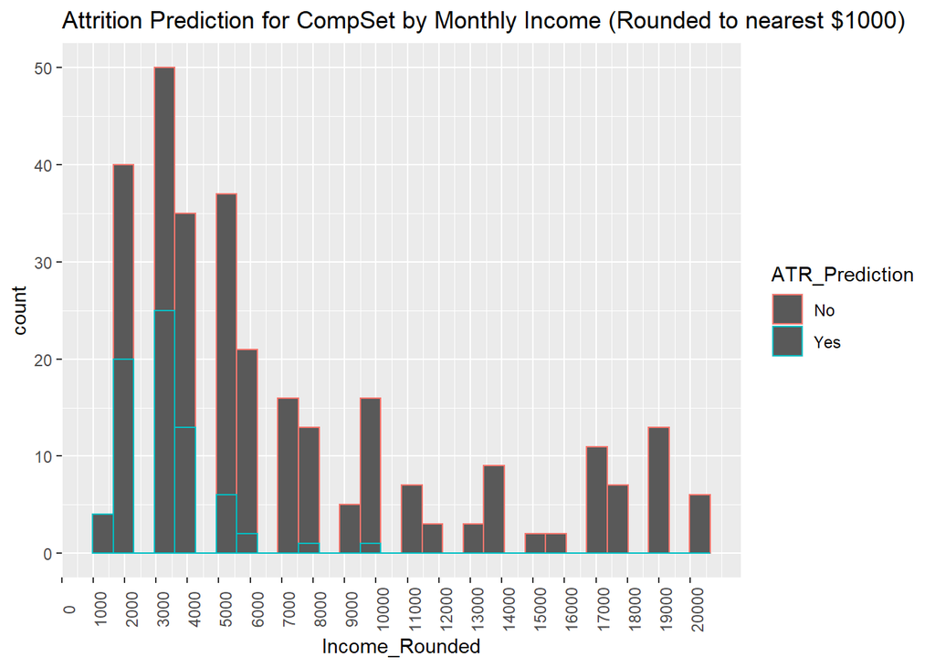

```r
CaseStudy2_CompSet_NoAtr%>%
  ggplot(aes(x=Income_Rounded,color=ATR_Prediction))+geom_histogram()+
  scale_x_continuous(breaks = round(seq(0,20000, by = 1000),2000))+
  theme(axis.text.x = element_text(angle = 90))+ggtitle("Attrition Prediction for CompSet by Monthly Income (Rounded to nearest $1000)")
```

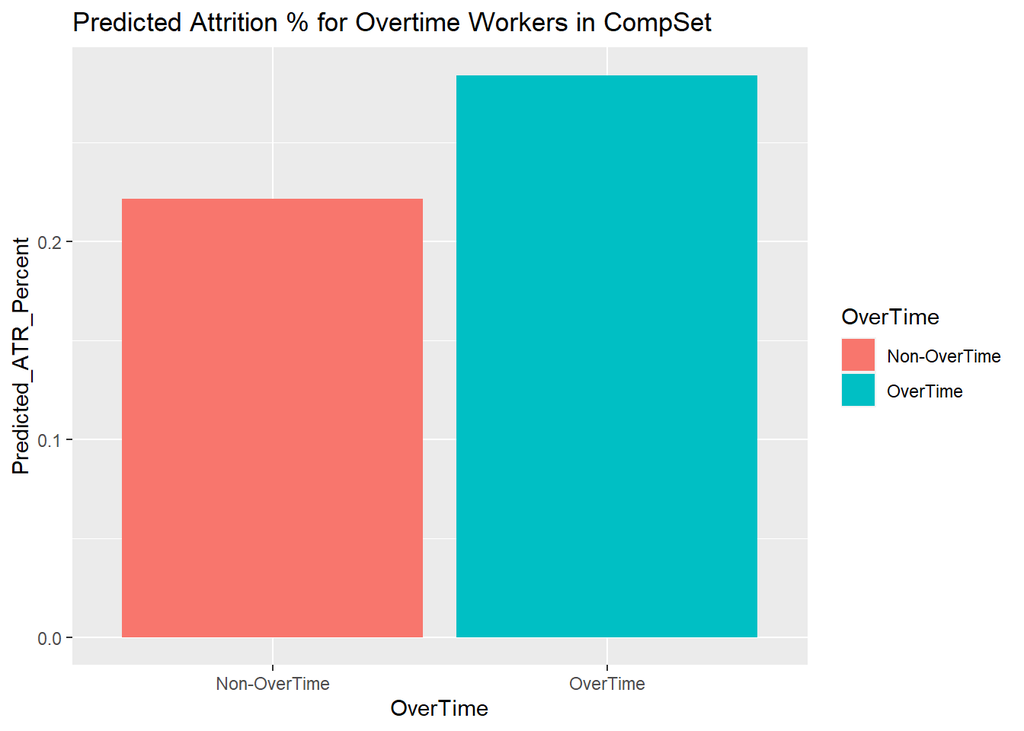

```r
data.frame(
 OverTime = c("OverTime","Non-OverTime") ,
'Pred_ATR_%' = c(nrow(CaseStudy2_CompSet_NoAtr%>%filter(ATR_Prediction=="Yes"&OverTime=="Yes"))/nrow(CaseStudy2_CompSet_NoAtr%>%filter(OverTime =="Yes")),nrow(CaseStudy2_CompSet_NoAtr%>%filter(ATR_Prediction=="Yes"&OverTime=="No"))/nrow(CaseStudy2_CompSet_NoAtr%>%filter(OverTime =="No")))
)%>%
  rename(
    'Predicted_ATR_Percent' = Pred_ATR_.)%>%ggplot(aes(x=OverTime,y=Predicted_ATR_Percent,fill=OverTime))+geom_col()+
  ggtitle("Predicted Attrition % for Overtime Workers in CompSet")
```

# Job Specific Trends

1. The following code provides Average Statistics by JobRole of key employee wellness measures by the following variables:
1. Job Satisfaction
2. Work Life Balance
3. Relationship Satisfaction
4. Environment Satisfaction
2. The code then does 2 sample two-tailed T-tests to determine the statistical significance of the highest & lowest rated job role from each wellness metric vs all other job roles
3. Only Environment Satisfaction of Manufacturing Director was revealed to be statistically significant (p-value = .004), other than this once case, it is statistically inconclusive to apply or assume the employee wellness trends from this sample to a larger population of employees.

```r
library(tidyverse)
library(knitr)
#install.packages("kableExtra")
library(kableExtra)


### Average Job Satisfaction statistics
JobSatisfaction <- CaseStudy2_data%>%group_by(JobRole)%>%summarize(Avg_JobSatisfaction=mean(JobSatisfaction),Count=n())%>%arrange(desc(Avg_JobSatisfaction))


JobSatisfaction <- (JobSatisfaction%>%mutate( Desc_Rank =
rank(-Avg_JobSatisfaction, na.last = TRUE,
     ties.method = c("first"))
, Asc_Rank =
rank(Avg_JobSatisfaction, na.last = TRUE,
     ties.method = c("first"))
))%>%mutate(JobRole_Desc = ifelse(Desc_Rank==1,JobRole,'All Other Roles'),
          JobRole_Asc = ifelse(Asc_Rank==1,JobRole,'All Other Roles')

          )


JobSatisfaction%>%select(JobRole,Avg_JobSatisfaction,Count)%>%
  kbl() %>%
  kable_classic_2(full_width = F)%>%
  add_header_above(c("Average Satisfaction by JobRole" = 3))
```

| Average Satisfaction by JobRole JobRole | Average Satisfaction by JobRole Avg_JobSatisfaction | Average Satisfaction by JobRole Count |
| --- | --- | --- |
| Healthcare Representative | 2.828947 | 76 |
| Research Scientist | 2.802326 | 172 |
| Sales Executive | 2.725000 | 200 |
| Manufacturing Director | 2.724138 | 87 |
| Sales Representative | 2.698113 | 53 |
| Laboratory Technician | 2.686275 | 153 |
| Human Resources | 2.555556 | 27 |
| Manager | 2.509804 | 51 |
| Research Director | 2.490196 | 51 |

```r
JobSatisfaction2 <- left_join(
CaseStudy2_data,
JobSatisfaction%>%select(JobRole,JobRole_Asc,JobRole_Desc),
by=c("JobRole"="JobRole"))



JobSatisfaction2_high <- t.test(formula =  JobSatisfaction ~ JobRole_Desc,  # Formula
       data = JobSatisfaction2)

JobSatisfaction2_low <- t.test(formula =  JobSatisfaction ~ JobRole_Asc,  # Formula
       data = JobSatisfaction2)


union_all(
JobSatisfaction%>%filter(Desc_Rank==1)%>%select(JobRole,Avg_JobSatisfaction,Count),

((JobSatisfaction%>%filter(!Desc_Rank==1)%>%mutate(count_percent=Count/(sum(JobSatisfaction%>%filter(!Desc_Rank==1)%>%summarize(Total_Count = sum(Count))%>%select(Total_Count)))  ))%>%
  mutate(WA = count_percent*Avg_JobSatisfaction )%>%summarize(Count=sum(Count),Avg_JobSatisfaction=sum(WA)))%>%mutate(JobRole="All Other Roles")%>%select(JobRole,Avg_JobSatisfaction,Count)

)%>%
  kbl() %>%
  kable_classic_2(full_width = F)%>%
  add_header_above(c("Highest Job Satisfaction Summary" = 3))
```

| Highest Job Satisfaction Summary JobRole | Highest Job Satisfaction Summary Avg_JobSatisfaction | Highest Job Satisfaction Summary Count |
| --- | --- | --- |
| Healthcare Representative | 2.828947 | 76 |
| All Other Roles | 2.697733 | 794 |

```r
union_all(
JobSatisfaction%>%filter(Asc_Rank==1)%>%select(JobRole,Avg_JobSatisfaction,Count),

((JobSatisfaction%>%filter(!Asc_Rank==1)%>%mutate(count_percent=Count/(sum(JobSatisfaction%>%filter(!Asc_Rank==1)%>%summarize(Total_Count = sum(Count))%>%select(Total_Count)))  ))%>%
  mutate(WA = count_percent*Avg_JobSatisfaction )%>%summarize(Count=sum(Count),Avg_JobSatisfaction=sum(WA)))%>%mutate(JobRole="All Other Roles")%>%select(JobRole,Avg_JobSatisfaction,Count)

)%>%
  kbl() %>%
  kable_classic_2(full_width = F)%>%
  add_header_above(c("Lowest Job Satisfaction Summary" = 3))
```

| Lowest Job Satisfaction Summary JobRole | Lowest Job Satisfaction Summary Avg_JobSatisfaction | Lowest Job Satisfaction Summary Count |
| --- | --- | --- |
| Research Director | 2.490196 | 51 |
| All Other Roles | 2.722833 | 819 |

```r
data.frame(
T_Test_Group = c("Highest Job Satisfaction","Lowest Job Satisfaction"),
T_Stat = c(JobSatisfaction2_high$statistic,JobSatisfaction2_low$statistic),
P_Value = c(JobSatisfaction2_high$p.value[1],JobSatisfaction2_low$p.value[1]),
'Confidence Interval low' = c(JobSatisfaction2_high$conf.int[1],JobSatisfaction2_low$conf.int[1]),
'Confidence Interval High' = c(JobSatisfaction2_high$conf.int[2],JobSatisfaction2_low$conf.int[2])
)%>%
  kbl() %>%
  kable_classic_2(full_width = F)%>%
  add_header_above(c("","T-Test Results 95% Confidence Level" = 4))
```

| T_Test_Group | T-Test Results 95% Confidence Level T_Stat | T-Test Results 95% Confidence Level P_Value | T-Test Results 95% Confidence Level Confidence.Interval.low | T-Test Results 95% Confidence Level Confidence.Interval.High |
| --- | --- | --- | --- | --- |
| Highest Job Satisfaction | -0.9548293 | 0.3422503 | -0.4042685 | 0.1418398 |
| Lowest Job Satisfaction | 1.4614688 | 0.1494211 | -0.0861702 | 0.5514435 |

```r
### Average work life balance statistics
WorkLifeBalance <- CaseStudy2_data%>%group_by(JobRole)%>%summarize(Avg_WorkLifeBalance=mean(WorkLifeBalance),Count=n())%>%arrange(desc(Avg_WorkLifeBalance))


WorkLifeBalance <- (WorkLifeBalance%>%mutate( Desc_Rank =
rank(-Avg_WorkLifeBalance, na.last = TRUE,
     ties.method = c("first"))
, Asc_Rank =
rank(Avg_WorkLifeBalance, na.last = TRUE,
     ties.method = c("first"))
))%>%mutate(JobRole_Desc = ifelse(Desc_Rank==1,JobRole,'All Other Roles'),
          JobRole_Asc = ifelse(Asc_Rank==1,JobRole,'All Other Roles')

          )


WorkLifeBalance%>%select(JobRole,Avg_WorkLifeBalance,Count)%>%
  kbl() %>%
  kable_classic_2(full_width = F)%>%
  add_header_above(c("Average Work/Life Balance by JobRole" = 3))
```

| Average Work/Life Balance by JobRole JobRole | Average Work/Life Balance by JobRole Avg_WorkLifeBalance | Average Work/Life Balance by JobRole Count |
| --- | --- | --- |
| Human Resources | 2.962963 | 27 |
| Sales Representative | 2.867924 | 53 |
| Research Director | 2.862745 | 51 |
| Manufacturing Director | 2.850575 | 87 |
| Sales Executive | 2.820000 | 200 |
| Laboratory Technician | 2.764706 | 153 |
| Manager | 2.764706 | 51 |
| Research Scientist | 2.691861 | 172 |
| Healthcare Representative | 2.671053 | 76 |

```r
WorkLifeBalance2 <- left_join(
CaseStudy2_data,
WorkLifeBalance%>%select(JobRole,JobRole_Asc,JobRole_Desc),
by=c("JobRole"="JobRole"))



WorkLifeBalance2_high <- t.test(formula =  WorkLifeBalance ~ JobRole_Desc,  # Formula
       data = WorkLifeBalance2)

WorkLifeBalance2_low <- t.test(formula =  WorkLifeBalance ~ JobRole_Asc,  # Formula
       data = WorkLifeBalance2)


union_all(
WorkLifeBalance%>%filter(Desc_Rank==1)%>%select(JobRole,Avg_WorkLifeBalance,Count),

((WorkLifeBalance%>%filter(!Desc_Rank==1)%>%mutate(count_percent=Count/(sum(WorkLifeBalance%>%filter(!Desc_Rank==1)%>%summarize(Total_Count = sum(Count))%>%select(Total_Count)))  ))%>%
  mutate(WA = count_percent*Avg_WorkLifeBalance )%>%summarize(Count=sum(Count),Avg_WorkLifeBalance=sum(WA)))%>%mutate(JobRole="All Other Roles")%>%select(JobRole,Avg_WorkLifeBalance,Count)

)%>%
  kbl() %>%
  kable_classic_2(full_width = F)%>%
  add_header_above(c("Highest Work/Life Balance Summary" = 3))
```

| Highest Work/Life Balance Summary JobRole | Highest Work/Life Balance Summary Avg_WorkLifeBalance | Highest Work/Life Balance Summary Count |
| --- | --- | --- |
| Human Resources | 2.962963 | 27 |
| All Other Roles | 2.775801 | 843 |

```r
union_all(
WorkLifeBalance%>%filter(Asc_Rank==1)%>%select(JobRole,Avg_WorkLifeBalance,Count),

((WorkLifeBalance%>%filter(!Asc_Rank==1)%>%mutate(count_percent=Count/(sum(WorkLifeBalance%>%filter(!Asc_Rank==1)%>%summarize(Total_Count = sum(Count))%>%select(Total_Count)))  ))%>%
  mutate(WA = count_percent*Avg_WorkLifeBalance )%>%summarize(Count=sum(Count),Avg_WorkLifeBalance=sum(WA)))%>%mutate(JobRole="All Other Roles")%>%select(JobRole,Avg_WorkLifeBalance,Count)

)%>%
  kbl() %>%
  kable_classic_2(full_width = F)%>%
  add_header_above(c("Lowest Work/Life Balance Summary" = 3))
```

| Lowest Work/Life Balance Summary JobRole | Lowest Work/Life Balance Summary Avg_WorkLifeBalance | Lowest Work/Life Balance Summary Count |
| --- | --- | --- |
| Healthcare Representative | 2.671053 | 76 |
| All Other Roles | 2.792191 | 794 |

```r
data.frame(
T_Test_Group = c("Highest Work/Life Satisfaction","Lowest Work/Life Satisfaction"),
T_Stat = c(WorkLifeBalance2_high$statistic,WorkLifeBalance2_low$statistic),
P_Value = c(WorkLifeBalance2_high$p.value[1],WorkLifeBalance2_low$p.value[1]),
'Confidence Interval low' = c(WorkLifeBalance2_high$conf.int[1],WorkLifeBalance2_low$conf.int[1]),
'Confidence Interval High' = c(WorkLifeBalance2_high$conf.int[2],WorkLifeBalance2_low$conf.int[2])
)%>%
  kbl() %>%
  kable_classic_2(full_width = F)%>%
  add_header_above(c("","T-Test Results 95% Confidence Level" = 4))
```

| T_Test_Group | T-Test Results 95% Confidence Level T_Stat | T-Test Results 95% Confidence Level P_Value | T-Test Results 95% Confidence Level Confidence.Interval.low | T-Test Results 95% Confidence Level Confidence.Interval.High |
| --- | --- | --- | --- | --- |
| Highest Work/Life Satisfaction | -1.469550 | 0.1528120 | -0.4480276 | 0.0737031 |
| Lowest Work/Life Satisfaction | 1.289143 | 0.2007739 | -0.0656402 | 0.3079178 |

```r
### Average Relationship Satisfaction statistics

RelationshipSatisfaction <- CaseStudy2_data%>%group_by(JobRole)%>%summarize(Avg_RelationshipSatisfaction=mean(RelationshipSatisfaction),Count=n())%>%arrange(desc(Avg_RelationshipSatisfaction))


RelationshipSatisfaction <- (RelationshipSatisfaction%>%mutate( Desc_Rank =
rank(-Avg_RelationshipSatisfaction, na.last = TRUE,
     ties.method = c("first"))
, Asc_Rank =
rank(Avg_RelationshipSatisfaction, na.last = TRUE,
     ties.method = c("first"))
))%>%mutate(JobRole_Desc = ifelse(Desc_Rank==1,JobRole,'All Other Roles'),
          JobRole_Asc = ifelse(Asc_Rank==1,JobRole,'All Other Roles')

          )


RelationshipSatisfaction%>%select(JobRole,Avg_RelationshipSatisfaction,Count)%>%
  kbl() %>%
  kable_classic_2(full_width = F)%>%
  add_header_above(c("Average Relationship Satisfaction by JobRole" = 3))
```

| Average Relationship Satisfaction by JobRole JobRole | Average Relationship Satisfaction by JobRole Avg_RelationshipSatisfaction | Average Relationship Satisfaction by JobRole Count |
| --- | --- | --- |
| Human Resources | 2.962963 | 27 |
| Manager | 2.803922 | 51 |
| Manufacturing Director | 2.770115 | 87 |
| Laboratory Technician | 2.732026 | 153 |
| Research Scientist | 2.686046 | 172 |
| Sales Executive | 2.685000 | 200 |
| Sales Representative | 2.660377 | 53 |
| Healthcare Representative | 2.644737 | 76 |
| Research Director | 2.588235 | 51 |

```r
RelationshipSatisfaction2 <- left_join(
CaseStudy2_data,
RelationshipSatisfaction%>%select(JobRole,JobRole_Asc,JobRole_Desc),
by=c("JobRole"="JobRole"))



RelationshipSatisfaction2_high <- t.test(formula =  RelationshipSatisfaction ~ JobRole_Desc,  # Formula
       data = RelationshipSatisfaction2)

RelationshipSatisfaction2_low <- t.test(formula =  RelationshipSatisfaction ~ JobRole_Asc,  # Formula
       data = RelationshipSatisfaction2)


union_all(
RelationshipSatisfaction%>%filter(Desc_Rank==1)%>%select(JobRole,Avg_RelationshipSatisfaction,Count),

((RelationshipSatisfaction%>%filter(!Desc_Rank==1)%>%mutate(count_percent=Count/(sum(RelationshipSatisfaction%>%filter(!Desc_Rank==1)%>%summarize(Total_Count = sum(Count))%>%select(Total_Count)))  ))%>%
  mutate(WA = count_percent*Avg_RelationshipSatisfaction )%>%summarize(Count=sum(Count),Avg_RelationshipSatisfaction=sum(WA)))%>%mutate(JobRole="All Other Roles")%>%select(JobRole,Avg_RelationshipSatisfaction,Count)

)%>%
  kbl() %>%
  kable_classic_2(full_width = F)%>%
  add_header_above(c("Highest Relationship Satisfaction Summary" = 3))
```

| Highest Relationship Satisfaction Summary JobRole | Highest Relationship Satisfaction Summary Avg_RelationshipSatisfaction | Highest Relationship Satisfaction Summary Count |
| --- | --- | --- |
| Human Resources | 2.962963 | 27 |
| All Other Roles | 2.698695 | 843 |

```r
union_all(
RelationshipSatisfaction%>%filter(Asc_Rank==1)%>%select(JobRole,Avg_RelationshipSatisfaction,Count),

((RelationshipSatisfaction%>%filter(!Asc_Rank==1)%>%mutate(count_percent=Count/(sum(RelationshipSatisfaction%>%filter(!Asc_Rank==1)%>%summarize(Total_Count = sum(Count))%>%select(Total_Count)))  ))%>%
  mutate(WA = count_percent*Avg_RelationshipSatisfaction )%>%summarize(Count=sum(Count),Avg_RelationshipSatisfaction=sum(WA)))%>%mutate(JobRole="All Other Roles")%>%select(JobRole,Avg_RelationshipSatisfaction,Count)

)%>%
  kbl() %>%
  kable_classic_2(full_width = F)%>%
  add_header_above(c("Lowest Relationship Satisfaction Summary" = 3))
```

| Lowest Relationship Satisfaction Summary JobRole | Lowest Relationship Satisfaction Summary Avg_RelationshipSatisfaction | Lowest Relationship Satisfaction Summary Count |
| --- | --- | --- |
| Research Director | 2.588235 | 51 |
| All Other Roles | 2.714286 | 819 |

```r
data.frame(
T_Test_Group = c("Highest Relationship Satisfaction","Lowest Relationship Satisfaction"),
T_Stat = c(RelationshipSatisfaction2_high$statistic,RelationshipSatisfaction2_low$statistic),
P_Value = c(RelationshipSatisfaction2_high$p.value[1],RelationshipSatisfaction2_low$p.value[1]),
'Confidence Interval low' = c(RelationshipSatisfaction2_high$conf.int[1],RelationshipSatisfaction2_low$conf.int[1]),
'Confidence Interval High' = c(RelationshipSatisfaction2_high$conf.int[2],RelationshipSatisfaction2_low$conf.int[2])
)%>%
  kbl() %>%
  kable_classic_2(full_width = F)%>%
  add_header_above(c("","T-Test Results 95% Confidence Level" = 4))
```

| T_Test_Group | T-Test Results 95% Confidence Level T_Stat | T-Test Results 95% Confidence Level P_Value | T-Test Results 95% Confidence Level Confidence.Interval.low | T-Test Results 95% Confidence Level Confidence.Interval.High |
| --- | --- | --- | --- | --- |
| Highest Relationship Satisfaction | -1.238244 | 0.2260075 | -0.7016358 | 0.1731002 |
| Lowest Relationship Satisfaction | 0.834620 | 0.4074016 | -0.1763491 | 0.4284500 |

```r
### Average Environmental Satisfaction statistics


EnvironmentSatisfaction <- CaseStudy2_data%>%group_by(JobRole)%>%summarize(Avg_EnvironmentSatisfaction=mean(EnvironmentSatisfaction),Count=n())%>%arrange(desc(Avg_EnvironmentSatisfaction))


EnvironmentSatisfaction <- (EnvironmentSatisfaction%>%mutate( Desc_Rank =
rank(-Avg_EnvironmentSatisfaction, na.last = TRUE,
     ties.method = c("first"))
, Asc_Rank =
rank(Avg_EnvironmentSatisfaction, na.last = TRUE,
     ties.method = c("first"))
))%>%mutate(JobRole_Desc = ifelse(Desc_Rank==1,JobRole,'All Other Roles'),
          JobRole_Asc = ifelse(Asc_Rank==1,JobRole,'All Other Roles')

          )


EnvironmentSatisfaction%>%select(JobRole,Avg_EnvironmentSatisfaction,Count)%>%
  kbl() %>%
  kable_classic_2(full_width = F)%>%
  add_header_above(c("Average Environment Satisfaction by JobRole" = 3))
```

| Average Environment Satisfaction by JobRole JobRole | Average Environment Satisfaction by JobRole Avg_EnvironmentSatisfaction | Average Environment Satisfaction by JobRole Count |
| --- | --- | --- |
| Manufacturing Director | 3.000000 | 87 |
| Laboratory Technician | 2.790850 | 153 |
| Healthcare Representative | 2.750000 | 76 |
| Human Resources | 2.703704 | 27 |
| Sales Representative | 2.660377 | 53 |
| Sales Executive | 2.640000 | 200 |
| Research Scientist | 2.627907 | 172 |
| Manager | 2.627451 | 51 |
| Research Director | 2.450980 | 51 |

```r
EnvironmentSatisfaction2 <- left_join(
CaseStudy2_data,
EnvironmentSatisfaction%>%select(JobRole,JobRole_Asc,JobRole_Desc),
by=c("JobRole"="JobRole"))



EnvironmentSatisfaction2_high <- t.test(formula =  EnvironmentSatisfaction ~ JobRole_Desc,  # Formula
       data = EnvironmentSatisfaction2)

EnvironmentSatisfaction2_low <- t.test(formula =  EnvironmentSatisfaction ~ JobRole_Asc,  # Formula
       data = EnvironmentSatisfaction2)


union_all(
EnvironmentSatisfaction%>%filter(Desc_Rank==1)%>%select(JobRole,Avg_EnvironmentSatisfaction,Count),

((EnvironmentSatisfaction%>%filter(!Desc_Rank==1)%>%mutate(count_percent=Count/(sum(EnvironmentSatisfaction%>%filter(!Desc_Rank==1)%>%summarize(Total_Count = sum(Count))%>%select(Total_Count)))  ))%>%
  mutate(WA = count_percent*Avg_EnvironmentSatisfaction )%>%summarize(Count=sum(Count),Avg_EnvironmentSatisfaction=sum(WA)))%>%mutate(JobRole="All Other Roles")%>%select(JobRole,Avg_EnvironmentSatisfaction,Count)

)%>%
  kbl() %>%
  kable_classic_2(full_width = F)%>%
  add_header_above(c("Highest Environment Satisfaction Summary" = 3))
```

| Highest Environment Satisfaction Summary JobRole | Highest Environment Satisfaction Summary Avg_EnvironmentSatisfaction | Highest Environment Satisfaction Summary Count |
| --- | --- | --- |
| Manufacturing Director | 3.000000 | 87 |
| All Other Roles | 2.667944 | 783 |

```r
union_all(
EnvironmentSatisfaction%>%filter(Asc_Rank==1)%>%select(JobRole,Avg_EnvironmentSatisfaction,Count),

((EnvironmentSatisfaction%>%filter(!Asc_Rank==1)%>%mutate(count_percent=Count/(sum(EnvironmentSatisfaction%>%filter(!Asc_Rank==1)%>%summarize(Total_Count = sum(Count))%>%select(Total_Count)))  ))%>%
  mutate(WA = count_percent*Avg_EnvironmentSatisfaction )%>%summarize(Count=sum(Count),Avg_EnvironmentSatisfaction=sum(WA)))%>%mutate(JobRole="All Other Roles")%>%select(JobRole,Avg_EnvironmentSatisfaction,Count)

)%>%
  kbl() %>%
  kable_classic_2(full_width = F)%>%
  add_header_above(c("Lowest Environment Satisfaction Summary" = 3))
```

| Lowest Environment Satisfaction Summary JobRole | Lowest Environment Satisfaction Summary Avg_EnvironmentSatisfaction | Lowest Environment Satisfaction Summary Count |
| --- | --- | --- |
| Research Director | 2.450980 | 51 |
| All Other Roles | 2.716728 | 819 |

```r
data.frame(
T_Test_Group = c("Highest Environment Satisfaction","Lowest Environment Satisfaction"),
T_Stat = c(EnvironmentSatisfaction2_high$statistic,EnvironmentSatisfaction2_low$statistic),
P_Value = c(EnvironmentSatisfaction2_high$p.value[1],EnvironmentSatisfaction2_low$p.value[1]),
'Confidence Interval low' = c(EnvironmentSatisfaction2_high$conf.int[1],EnvironmentSatisfaction2_low$conf.int[1]),
'Confidence Interval High' = c(EnvironmentSatisfaction2_high$conf.int[2],EnvironmentSatisfaction2_low$conf.int[2])
)%>%
  kbl() %>%
  kable_classic_2(full_width = F)%>%
  add_header_above(c("","T-Test Results 95% Confidence Level" = 4))
```

| T_Test_Group | T-Test Results 95% Confidence Level T_Stat | T-Test Results 95% Confidence Level P_Value | T-Test Results 95% Confidence Level Confidence.Interval.low | T-Test Results 95% Confidence Level Confidence.Interval.High |
| --- | --- | --- | --- | --- |
| Highest Environment Satisfaction | -2.936025 | 0.0040394 | -0.5561571 | -0.1079553 |
| Lowest Environment Satisfaction | 1.556387 | 0.1253119 | -0.0763817 | 0.6078764 |

```r
data.frame(
Employee_Wellness_Metric = c("Job Satisfaction", "Work/Life Balance", "Relationship Satisfaction","Environmental Satisfaction"),
Highest_Rated_Role = c("Healthcare Representative","Human Resources","Human Resources","Manufacturing Director"),
Highest_Rated_Avg = c(2.828947,2.962963,2.962963,3.000000),
Lowest_Rated_Role = c("Research Director","Healthcare Representative","Research Director","Research Director"),
Lowest_Rated_Avg = c(2.490196,2.671053,2.588235,2.450980)
)%>%
  kbl() %>%
  kable_classic_2(full_width = F)%>%
  add_header_above(c("Employee Wellness Summary" = 5))
```

| Employee Wellness Summary Employee_Wellness_Metric | Employee Wellness Summary Highest_Rated_Role | Employee Wellness Summary Highest_Rated_Avg | Employee Wellness Summary Lowest_Rated_Role | Employee Wellness Summary Lowest_Rated_Avg |
| --- | --- | --- | --- | --- |
| Job Satisfaction | Healthcare Representative | 2.828947 | Research Director | 2.490196 |
| Work/Life Balance | Human Resources | 2.962963 | Healthcare Representative | 2.671053 |
| Relationship Satisfaction | Human Resources | 2.962963 | Research Director | 2.588235 |
| Environmental Satisfaction | Manufacturing Director | 3.000000 | Research Director | 2.450980 |

```r
data.frame(
Employee_Wellness_Metric = c("Job Satisfaction", "Work/Life Balance", "Relationship Satisfaction","Environmental Satisfaction"),
Highest_Rated_Role = c("Healthcare Representative","Human Resources","Human Resources","Manufacturing Director"),
Highest_Rated_Avg = c(2.828947,2.962963,2.962963,3.000000),
Statistically_Significant = c("No","No","No","Yes"),
Lowest_Rated_Role = c("Research Director","Healthcare Representative","Research Director","Research Director"),
Lowest_Rated_Avg = c(2.490196,2.671053,2.588235,2.450980),
Statistically_Significant = c("No","No","No","No")
)%>%
  kbl() %>%
  kable_classic_2(full_width = F)%>%
  add_header_above(c("Employee Wellness Summary" = 7))
```

| Employee Wellness Summary Employee_Wellness_Metric | Employee Wellness Summary Highest_Rated_Role | Employee Wellness Summary Highest_Rated_Avg | Employee Wellness Summary Statistically_Significant | Employee Wellness Summary Lowest_Rated_Role | Employee Wellness Summary Lowest_Rated_Avg | Employee Wellness Summary Statistically_Significant.1 |
| --- | --- | --- | --- | --- | --- | --- |
| Job Satisfaction | Healthcare Representative | 2.828947 | No | Research Director | 2.490196 | No |
| Work/Life Balance | Human Resources | 2.962963 | No | Healthcare Representative | 2.671053 | No |
| Relationship Satisfaction | Human Resources | 2.962963 | No | Research Director | 2.588235 | No |
| Environmental Satisfaction | Manufacturing Director | 3.000000 | Yes | Research Director | 2.450980 | No |

# Monthly Income Regression Model

Similar to Attrition, there are many variables that contribute to determining Monthly Income, there are at least 27 different continuous variables that could play a part in Monthly Income determination.

1. The following code used step-wise selection process was done to ensure only the most statistically significant coefficients that yielded the highest Adjusted R squared and lowest root mean squared error were included in the model.
2. The step-wise selection method yields 8 coefficients that will be used to predict monthly income. When running the model on the whole data set the Adjusted R^2 and RMSE are .91 and 1362.277 respectively
3. The model shows Joblevel, TotalWorkingYears and YearswithCurrentManager as 3 of the most influential variables.
4. A data frame is created showing the Pearson Coefficient for each of these variables.

```r
library(e1071)
library(class)
library(caret)
#install.packages("Metrics")
library(Metrics)
library(tidyverse)
library(knitr)
#install.packages("kableExtra")
library(kableExtra)




employee_data <- (CaseStudy2_data[, sapply(CaseStudy2_data, class) != "character"])

employee_data <- employee_data[,!names(employee_data) %in% c("StandardHours", "Income_Rounded")]






#Model1_fit = lm(MonthlyIncome ~ JobLevel+Age+YearsAtCompany, data = CaseStudy2_data)

#summary(Model1_fit)
#Model1_Preds = predict(Model1_fit, newdata = CaseStudy2_data)


#rmse(CaseStudy2_data$MonthlyIncome, Model1_Preds)



library(MASS)
# Fit the full model
full.model <- lm(MonthlyIncome ~., data = employee_data)
#summary(full.model)
# Stepwise regression model
step.model <- stepAIC(full.model, direction = "both",
                      trace = FALSE)
employee_data_summary<- summary(step.model)

detach("package:MASS", unload=TRUE)



employee_data_df <- as.data.frame(employee_data_summary$coefficients)
Model1_Preds = predict(step.model, newdata = CaseStudy2_data)


employee_data_df%>%
  kbl() %>%
  kable_classic_2(full_width = F)%>%
  add_header_above(c("Step-Wise Coefficients of Linear Regression Model for Monthly Income" = 5))
```

| Step-Wise Coefficients of Linear Regression Model for Monthly Income | Step-Wise Coefficients of Linear Regression Model for Monthly Income Estimate | Step-Wise Coefficients of Linear Regression Model for Monthly Income Std. Error | Step-Wise Coefficients of Linear Regression Model for Monthly Income t value | Step-Wise Coefficients of Linear Regression Model for Monthly Income Pr(>\|t\|) |
| --- | --- | --- | --- | --- |
| (Intercept) | -1177.30266 | 513.798302 | -2.291371 | 0.0221827 |
| DistanceFromHome | -16.03527 | 5.726828 | -2.800026 | 0.0052242 |
| EnvironmentSatisfaction | -71.64538 | 42.316330 | -1.693091 | 0.0908000 |
| JobInvolvement | 106.62742 | 66.046900 | 1.614420 | 0.1068028 |
| JobLevel | 3728.47184 | 68.275895 | 54.608905 | 0.0000000 |
| PercentSalaryHike | 32.99851 | 20.074827 | 1.643776 | 0.1005876 |
| PerformanceRating | -311.91448 | 205.069981 | -1.521015 | 0.1286233 |
| TotalWorkingYears | 67.61163 | 10.384643 | 6.510732 | 0.0000000 |
| YearsWithCurrManager | -59.89150 | 14.676295 | -4.080832 | 0.0000490 |

```r
data.frame(
Adj_R_Squared = c(employee_data_summary$adj.r.squared),
RMSE = c(rmse(CaseStudy2_data$MonthlyIncome, Model1_Preds)))%>%
  kbl() %>%
  kable_classic_2(full_width = F)%>%
  add_header_above(c("Step-Wise Model Accuracy" = 2))
```

| Step-Wise Model Accuracy Adj_R_Squared | Step-Wise Model Accuracy RMSE |
| --- | --- |
| 0.9112912 | 1362.277 |

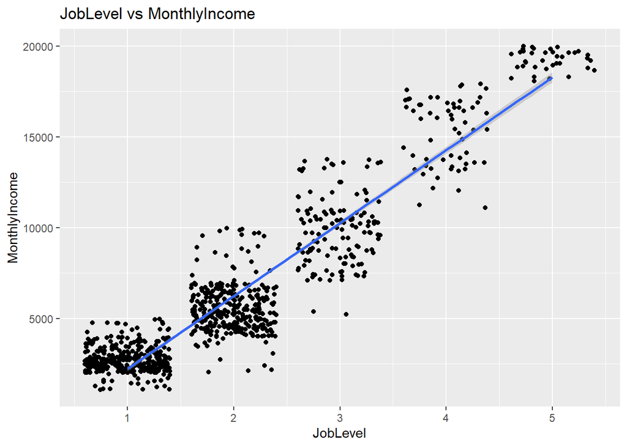

```r
CaseStudy2_data%>%ggplot(aes(x=JobLevel,y=MonthlyIncome))+geom_point(position = "jitter")+geom_smooth(method="lm")+ggtitle("JobLevel vs MonthlyIncome")
```

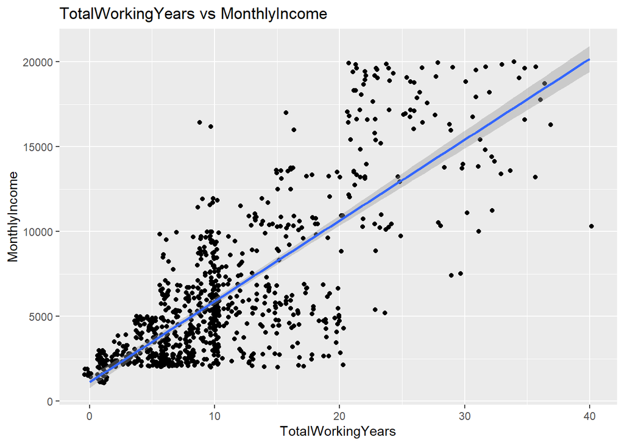

```r
CaseStudy2_data%>%ggplot(aes(x=TotalWorkingYears,y=MonthlyIncome))+geom_point(position = "jitter")+geom_smooth(method="lm")+ggtitle("TotalWorkingYears vs MonthlyIncome")
```

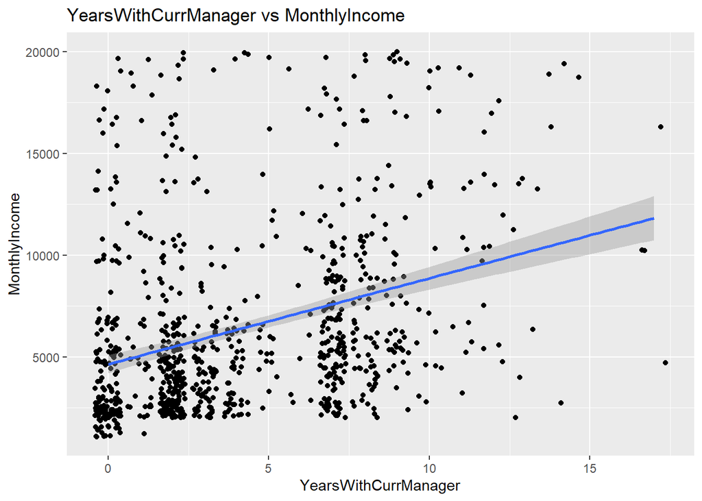

```r
CaseStudy2_data%>%ggplot(aes(x=YearsWithCurrManager,y=MonthlyIncome))+geom_point(position = "jitter")+geom_smooth(method="lm")+ggtitle("YearsWithCurrManager vs MonthlyIncome")
```

```r
data.frame(
Variable = c("JobLevel","TotalWorkingYears","YearsWithCurrManager"),
Pearson_Coefficient = c(
cor(CaseStudy2_data$JobLevel, CaseStudy2_data$MonthlyIncome, method = c("pearson")),
cor(CaseStudy2_data$TotalWorkingYears, CaseStudy2_data$MonthlyIncome, method = c("pearson")),
cor(CaseStudy2_data$YearsWithCurrManager, CaseStudy2_data$MonthlyIncome, method = c("pearson"))))%>%
  kbl() %>%
  kable_classic_2(full_width = F)%>%
  add_header_above(c("Linear Fit Assessment" = 2))
```

| Linear Fit Assessment Variable | Linear Fit Assessment Pearson_Coefficient |
| --- | --- |
| JobLevel | 0.9516400 |
| TotalWorkingYears | 0.7785112 |
| YearsWithCurrManager | 0.3284875 |

# Monthly Income Regression Model (Cross-Validation)

The code below will test the accuracy of the coefficient selection from the step-wise model.

1. 500 iterations of 70/30 test & training sets are created to test the consistency of the regression model
1. In each test set the adjusted R-squared and RMSE of the model are stored
2. In each training set the adjusted R-squared and RMSE of the model are stored
2. A data frame is created showing the average of the 500 tests for adjusted R-squared and RMSE for test and training sets. The values are very similar to that of the original step-wise model validating its accuracy
3. Histograms show the normal distribution and consistency of measurements across the 500 iterations pf test/train for adj. R^2 and RMSE

```r
library(e1071)
library(class)
library(caret)
#install.packages("Metrics")
library(Metrics)
library(tidyverse)
library(knitr)
#install.packages("kableExtra")
library(kableExtra)






iterations_RM = 500
train_AdjR_RM = matrix(nrow = iterations_nb)
train_RMSE_RM = matrix(nrow = iterations_nb)
test_AdjR_RM = matrix(nrow = iterations_nb)
test_RMSE_RM = matrix(nrow = iterations_nb)
splitPerc = .7 #Training / Test split Percentage
for(j in 1:iterations_nb)
{

  trainIndices_RM = sample(1:dim(CaseStudy2_data)[1],round(splitPerc * dim(CaseStudy2_data)[1]))
  train_RM = CaseStudy2_data[trainIndices_RM,]
  test_RM = CaseStudy2_data[-trainIndices_RM,]

  library(MASS)

train_RM_model <- lm(MonthlyIncome ~ DistanceFromHome + EnvironmentSatisfaction + JobInvolvement + JobLevel + PercentSalaryHike + PerformanceRating + TotalWorkingYears + YearsWithCurrManager , data = train_RM)

detach("package:MASS", unload=TRUE)


train_RM_model_summary <- summary(train_RM_model)

 train_RM_Preds = predict(train_RM_model, newdata = train_RM)
 test_RM_Preds = predict(train_RM_model, newdata = test_RM)


  train_AdjR_RM[j] = train_RM_model_summary$adj.r.squared
  train_RMSE_RM[j] = rmse(train_RM$MonthlyIncome, train_RM_Preds)

test_RM_residuals <-test_RM$MonthlyIncome-test_RM_Preds

 n_test=length(test_RM$MonthlyIncome)
k_test=length(train_RM_model$coefficients)-1 #Subtract one to ignore intercept
SSE_test=sum(test_RM_residuals**2)
SSyy_test=sum((test_RM$MonthlyIncome-mean(test_RM$MonthlyIncome))**2)
test_AdjR <- 1-(SSE_test/SSyy_test)*(n_test-1)/(n_test-(k_test+1))

test_AdjR_RM[j] = test_AdjR
test_RMSE_RM[j] = rmse(test_RM$MonthlyIncome, test_RM_Preds)

}


Mean_train_AdjR_RM = colMeans(train_AdjR_RM)
Mean_train_RMSE_RM = colMeans(train_RMSE_RM)
Mean_test_AdjR_RM = colMeans(test_AdjR_RM)
Mean_test_RMSE_RM = colMeans(test_RMSE_RM)


 RM_results <- data.frame(
   Measurenment = c("Train_Set_Adj_Rsquared_Avg","Train_Set_RMSE_Avg","Test_Set_Adj_Rsquared_Avg","Test_Set_RMSE_Avg"),
   Value = c(Mean_train_AdjR_RM,Mean_train_RMSE_RM,Mean_test_AdjR_RM,Mean_test_RMSE_RM ))


 RM_results%>%
  kbl() %>%
  kable_classic_2(full_width = F)%>%
  add_header_above(c("500 iterations of 70/30 Train & Test split Cross-Validation" = 2))
```

| 500 iterations of 70/30 Train & Test split Cross-Validation Measurenment | 500 iterations of 70/30 Train & Test split Cross-Validation Value |
| --- | --- |
| Train_Set_Adj_Rsquared_Avg | 0.9110662 |
| Train_Set_RMSE_Avg | 1357.9173295 |
| Test_Set_Adj_Rsquared_Avg | 0.9060568 |
| Test_Set_RMSE_Avg | 1381.4178370 |

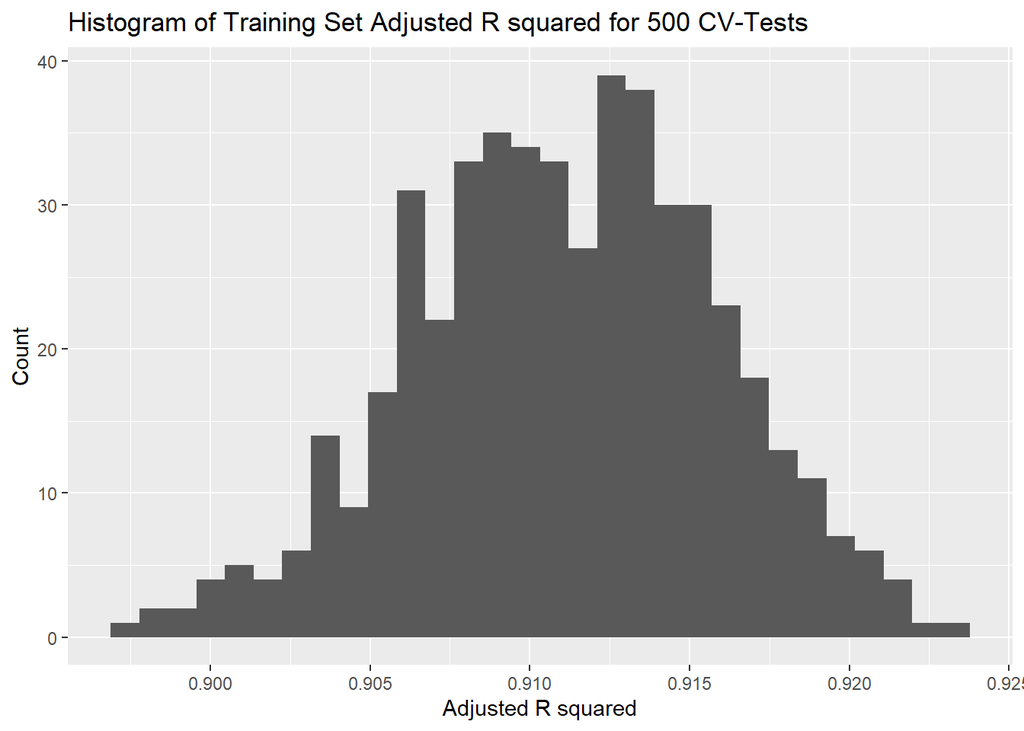

```r
as.data.frame(train_AdjR_RM)%>%ggplot(aes(x=V1))+geom_histogram()+xlab("Adjusted R squared")+ylab("Count")+ggtitle("Histogram of Training Set Adjusted R squared for 500 CV-Tests")
```

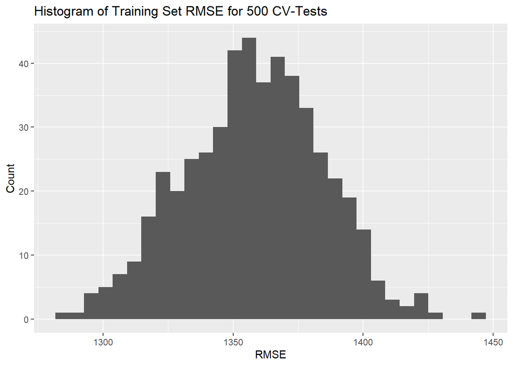

```r
as.data.frame(train_RMSE_RM)%>%ggplot(aes(x=V1))+geom_histogram()+xlab("RMSE")+ylab("Count")+ggtitle("Histogram of Training Set RMSE for 500 CV-Tests")
```

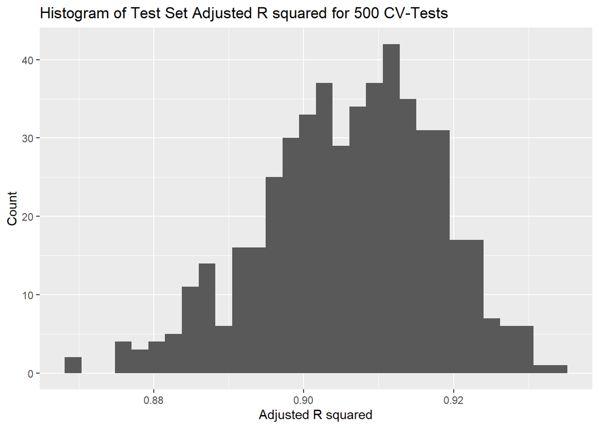

```r
as.data.frame(test_AdjR_RM)%>%ggplot(aes(x=V1))+geom_histogram()+xlab("Adjusted R squared")+ylab("Count")+ggtitle("Histogram of Test Set Adjusted R squared for 500 CV-Tests")
```

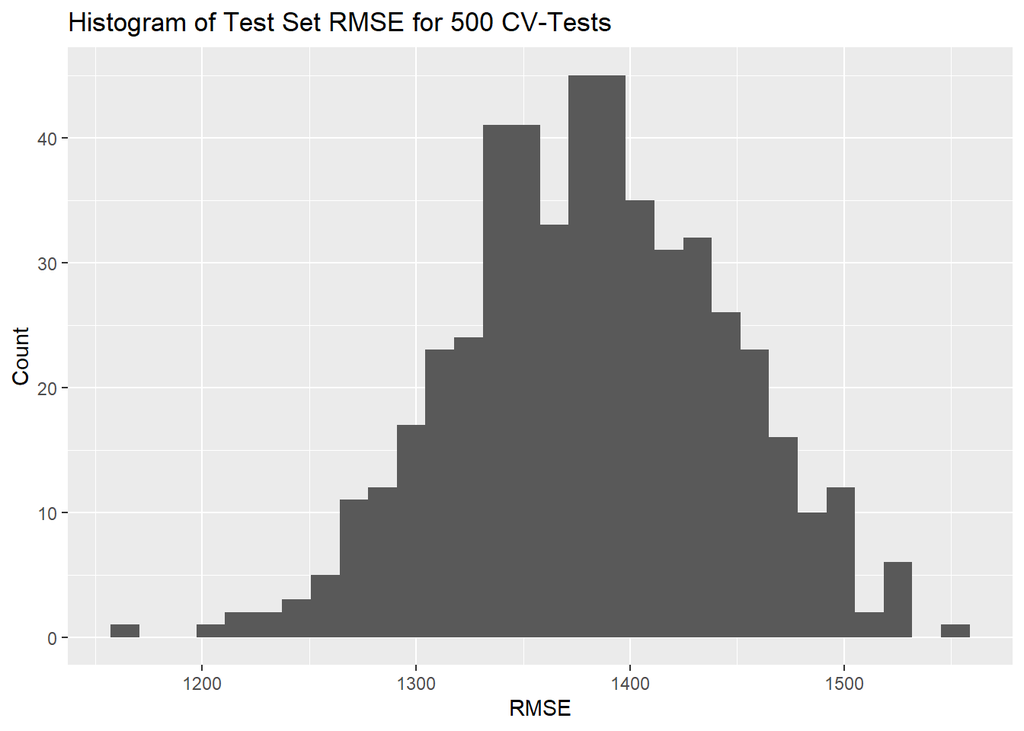

```r
as.data.frame(test_RMSE_RM)%>%ggplot(aes(x=V1))+geom_histogram()+xlab("RMSE")+ylab("Count")+ggtitle("Histogram of Test Set RMSE for 500 CV-Tests")
```

# Monthly Income Regression Model (Prediction)

The code below will run the cross-validated step-wise regression model for Monthly Income on the provided Compset.

1. Scatter plots are created to show the consistency with the linear trends identified with JobLevel, TotalWorkingYears and YearsWithCurrManager from the original Dataset.
2. In addition a data frame is created showing the summary of Pearson Linear coefficients from the original Dataset with that of the Compset with predicted Monthly Income
3. The data summarized here provides confidence that Monthly Income was estimated accurately and is following the same trends as identified in the original data.

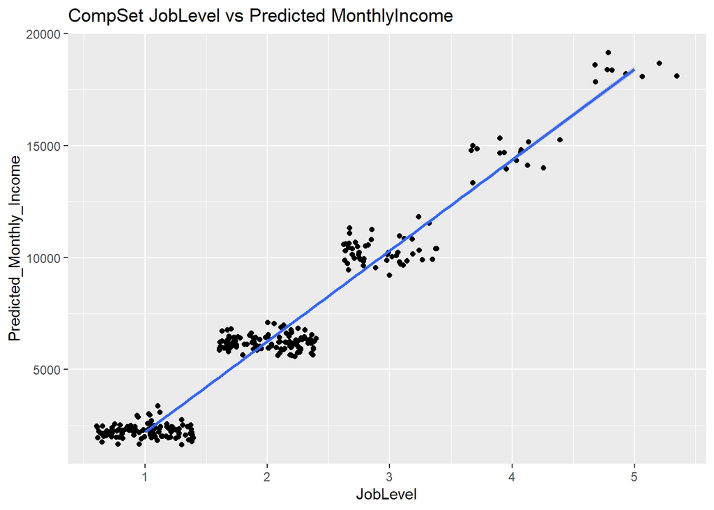

```r
CaseStudy2_CompSet_NoSal_Preds = predict(step.model, newdata = CaseStudy2_CompSet_NoSal)

CaseStudy2_CompSet_NoSal$Predicted_Monthly_Income = CaseStudy2_CompSet_NoSal_Preds


CaseStudy2_CompSet_NoSal%>%ggplot(aes(x=JobLevel,y=Predicted_Monthly_Income))+geom_point(position = "jitter")+geom_smooth(method="lm")+ggtitle("CompSet JobLevel vs Predicted MonthlyIncome")
```

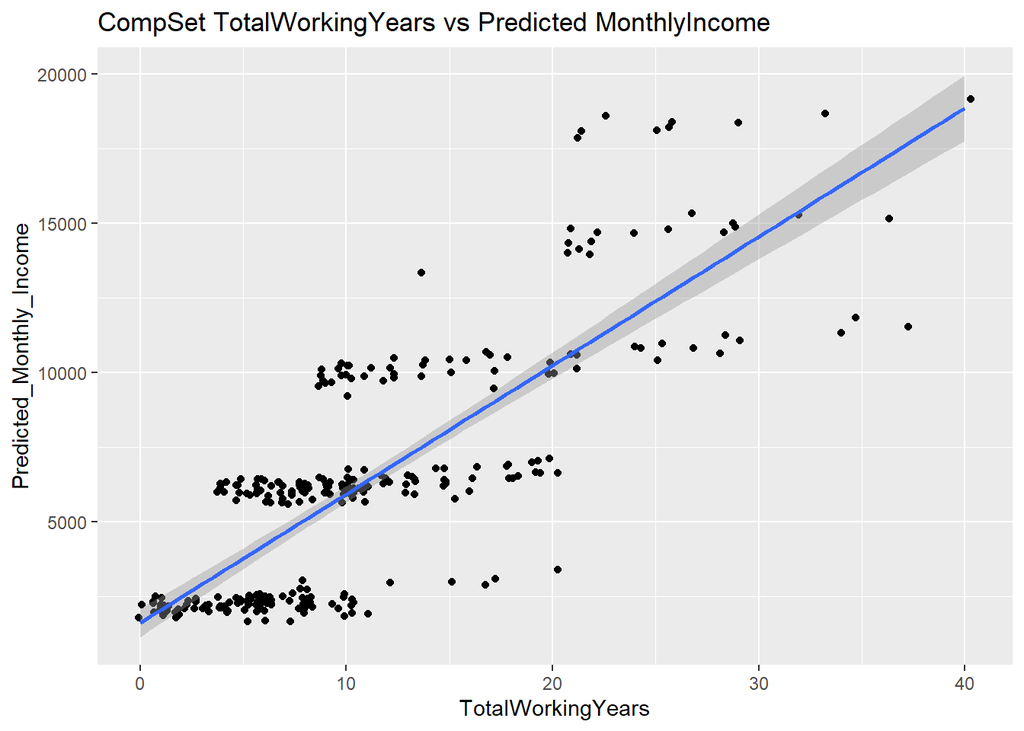

```r
CaseStudy2_CompSet_NoSal%>%ggplot(aes(x=TotalWorkingYears,y=Predicted_Monthly_Income))+geom_point(position = "jitter")+geom_smooth(method="lm")+ggtitle("CompSet TotalWorkingYears vs Predicted MonthlyIncome")
```

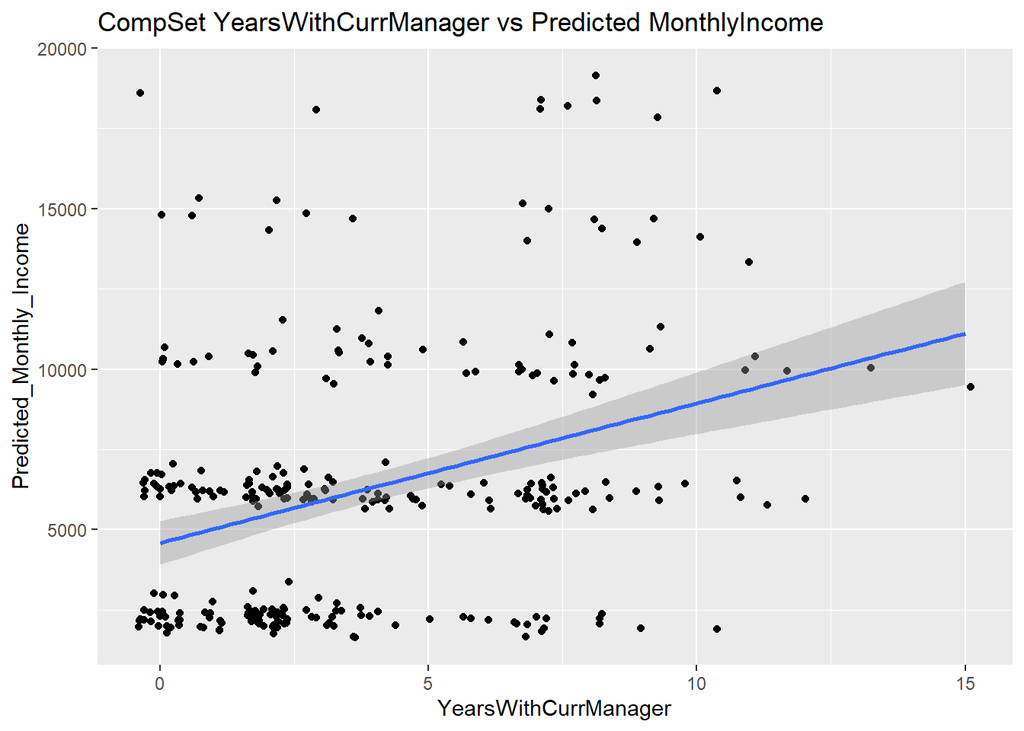

```r
CaseStudy2_CompSet_NoSal%>%ggplot(aes(x=YearsWithCurrManager,y=Predicted_Monthly_Income))+geom_point(position = "jitter")+geom_smooth(method="lm")+ggtitle("CompSet YearsWithCurrManager vs Predicted MonthlyIncome")
```

```r
data.frame(
Variable = c("JobLevel","TotalWorkingYears","YearsWithCurrManager"),
Original_Data_Pearson_Coefficient = c(
cor(CaseStudy2_data$JobLevel, CaseStudy2_data$MonthlyIncome, method = c("pearson")),
cor(CaseStudy2_data$TotalWorkingYears, CaseStudy2_data$MonthlyIncome, method = c("pearson")),
cor(CaseStudy2_data$YearsWithCurrManager, CaseStudy2_data$MonthlyIncome, method = c("pearson"))),
CompSet_Predicted_Pearson_Coefficient = c(
cor(CaseStudy2_CompSet_NoSal$JobLevel, CaseStudy2_CompSet_NoSal$Predicted_Monthly_Income, method = c("pearson")),
cor(CaseStudy2_CompSet_NoSal$TotalWorkingYears, CaseStudy2_CompSet_NoSal$Predicted_Monthly_Income, method = c("pearson")),
cor(CaseStudy2_CompSet_NoSal$YearsWithCurrManager, CaseStudy2_CompSet_NoSal$Predicted_Monthly_Income, method = c("pearson")))


)%>%
  kbl() %>%
  kable_classic_2(full_width = F)%>%
  add_header_above(c("Linear Fit Assessment" = 3))
```

| Linear Fit Assessment Variable | Linear Fit Assessment Original_Data_Pearson_Coefficient | Linear Fit Assessment CompSet_Predicted_Pearson_Coefficient |
| --- | --- | --- |
| JobLevel | 0.9516400 | 0.9956813 |
| TotalWorkingYears | 0.7785112 | 0.8036621 |
| YearsWithCurrManager | 0.3284875 | 0.3372129 |

```r
Case2PredictionsZaikenSalary <- CaseStudy2_CompSet_NoSal%>%mutate(MonthlyIncome = Predicted_Monthly_Income)%>%select(ID,MonthlyIncome)
```

# Export of CompSet CSV files

The following code will export CSV file formats for the predicted Attrition and Estimated Monthly Income for the 2 CompSets.

```r
#write.csv(Case2PredictionsZaiken,"C:\\Users\\zzaik\\OneDrive\\SMU work\\Doing Data Science\\Case Study 2\\Case2PredictionsZaiken Attrition.csv", row.names = FALSE)

#write.csv(Case2PredictionsZaikenSalary,"C:\\Users\\zzaik\\OneDrive\\SMU work\\Doing Data Science\\Case Study 2\\Case2PredictionsZaiken Salary.csv", row.names = FALSE)
```